# Mixed model lab #1

Ben Bolker

07:12 29 April 2016

## Preliminaries

Licensed under the [Creative Commons attribution-noncommercial license](http://creativecommons.org/licenses/by-nc-sa/2.5/ca/). Please share & remix noncommercially, mentioning its origin.

Packages/versions used:

```
##     coda glmmADMB     lme4 MCMCglmm     nlme pbkrtest     plyr   R2jags
##   0.18-1  0.8.3.3   1.1-12   2.22.1  3.1-126    0.4-6    1.8.3    0.5-7
## reshape2
##    1.4.1
```

Load packages:

```r
## modeling packages
library("lme4")     ## basic (G)LMMs
library("MCMCglmm") ## Bayesian GLMMs
library("nlme")     ## more LMMs
library("afex")     ## helper functions

## graphics
library("ggplot2"); theme_set(theme_bw())
## squash panels together
zero_margin <- theme(panel.margin=grid::unit(0,"lines"))
library("lattice")
library("dotwhisker")  ## coefficient plots
## data manipulation
library("broom")
library("reshape2")
library("plyr")
```

## Linear mixed model: starling example

Data from Toby Marthews, [r-sig-mixed-models mailing list](http://tolstoy.newcastle.edu.au/R/e13/help/11/01/1364.html): you can find it [here](https://github.com/bbolker/upr_2016/tree/master/lab/data).

### Graphics: spaghetti plots

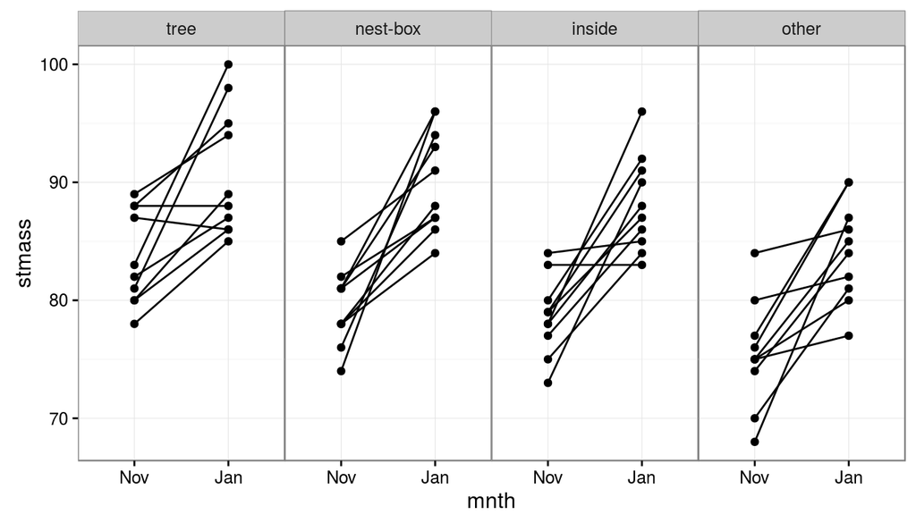

```r
## cosmetic tweaks
load("data/starling.RData")   ## loads "dataf"
ggplot(dataf,aes(x=mnth,y=stmass))+
  geom_point()+
  geom_line(aes(group=subject))+  ## connect subjects with a line
  facet_grid(.~roostsitu)+        ## 1 row of panels by roost
  zero_margin                         ## squash together
```

You should also try

```r
ggplot(dataf,aes(mnth,stmass,colour=roostsitu))+
    geom_point()+
    geom_line(aes(group=subject))
```

for comparison, but I prefer the former plot.

Overkill for this data set, but sometimes it can be useful to put every individual in its own facet:

```r
## reorder individuals by difference
dataf <- transform(dataf,subject=reorder(subject,stmass,FUN=diff))
ggplot(dataf,aes(mnth,stmass,colour=roostsitu,group=subject))+
  geom_point()+geom_line()+facet_wrap(~subject)+
    zero_margin
```

It’s pretty obvious that the starting (November) mass varies among roost situations (tree/nest-box/etc.), and that mass increases from November to January, but we might like to know if the slopes differ among situations. That means our fixed effects would be `~roostsitu*mnth`, with our attention focused on the `roostsitu:mnth` (interaction) term. For random effects, we can allow both intercept (obviously) and slope (maybe) to vary among individuals, via `(1+mnth|subject)` or equivalent … in this case, because measurements are only taken in two months, we can also write the random term as `(1|subject/mnth)`. **However**, it turns out that we can’t actually estimate random slopes for this model, because every individual is only measured twice. That means that the variance in the slopes would be completely confounded with the residual variance.

If we fit this with lme4

```r
lme1 <- lmer(stmass~mnth*roostsitu+(1|subject/mnth),data=dataf)
```

```
## Error: number of levels of each grouping factor must be < number of observations
```

We get an error: if we fit this with

```r
lme(stmass~mnth*roostsitu, random= ~1|subject/mnth,data=dataf)
```

it lets us do it, silently (but runs into trouble farther down the road). We *can* actually do this (`lmerControl(check.nobs.vs.nlev="ignore")`; see `?lmerControl` for details), and it will actually work, but it will pick an arbitrary division between the residual variance and the `month:subject` variance.

But now let’s forget about including the (unidentifiable) random slopes.

```r
lmer2 <- lmer(stmass~mnth*roostsitu+(1|subject),data=dataf)
```

We can now get estimates, although the subject-level random effects are *very* uncertain: see `confint(lmer2)`

Walking through the output:

```
## Linear mixed model fit by REML ['lmerMod']
## Formula: stmass ~ mnth * roostsitu + (1 | subject)
##    Data: dataf
##
## REML criterion at convergence: 429.6
```

- This gives us the formula, reminds us that the model was fitted by restricted maximum likelihood, and gives us the “REML criterion” (equivalent to -2 log likelihood for a model fitted by maximum likelihood).

```
##
## Scaled residuals:
##     Min      1Q  Median      3Q     Max
## -1.7555 -0.7687 -0.0864  0.7022  2.1693
```

This is a quick reminder of the scaled residuals; these should be approximately unskewed (median $\approx 0$) and the extremes should be somewhere around $\pm 2$ (bigger in a big data set )

```
## Random effects:
##  Groups   Name        Variance Std.Dev.
##  subject  (Intercept)  0.3444  0.5869
##  Residual             17.3500  4.1653
```

- This tells us about the random effect - it tells us the variances and standard deviations of the random effect (the standard deviations are *not* an estimate of the uncertainty of the estimate – the estimate itself *is* a variance, or standard deviation), and the variance and standard deviation of the residual variance. We can see that the standard deviation of the intercept among subjects is much less than the standard deviation of the residual error …

```
## Number of obs: 80, groups:  subject, 40
```

- The listed number of observations and groups is *very* useful for double-checking that the random effects grouping specification is OK. Are the numbers of groups what we expected from the experimental design?

[output not shown]

- the standard fixed-effect output. `lmer` does *not* tell us the denominator degrees of freedom for the test (although we can get a rough idea of importance/significance fro the $t$ statistics; e.g. $t>2.5$ will be significant at $p<0.05$ for 6 or more degrees of freedom). We’ll come back to this in the inference section.

## Diagnostic plots

Basic diagnostic plots: fitted vs. residuals, coloured according to the `roostsitu` variable:

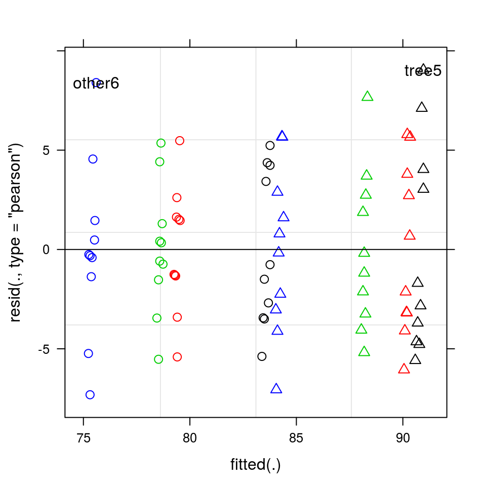

```r
plot(lmer2,col=dataf$roostsitu,pch=dataf$mnth,id=0.05)
```

The `id` argument specifies to mark points that are beyond the specified Normal confidence limits (i.e. $\alpha$-values) (these are not outliers in any formal statistical sense but might be points you want to look at if they are otherwise interesting). By default they are labeled by random-effect group; use `idLabels` to change the default labels, and `idLabels=~.obs` to label by observation number.

You can get a scale-location plot by specifying

```r
plot(lmer2,sqrt(abs(residuals(.))) ~ fitted(.),type=c("p","smooth"))
```

Adding the smoothed line is helpful because uneven sampling can influence your perception of the pattern.

Q-Q plot (a straight line indicates normality)

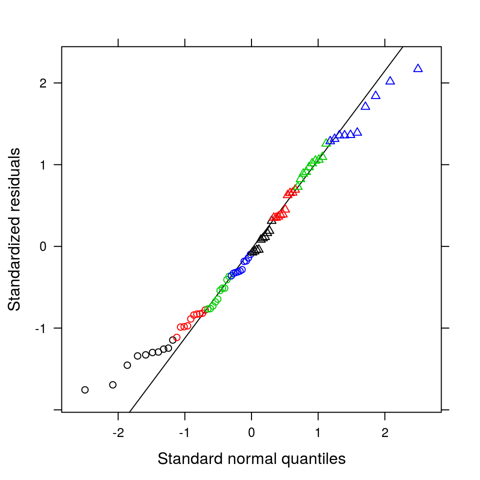

```r
qqmath(lmer2,col=dataf$roostsitu,pch=dataf$mnth)
```

```r
ggplot(augment(lmer2),
       aes(sample=.resid/sd(.resid)))+  ## scale to variance=1
        stat_qq(aes(group=1,colour=roostsitu))+
    geom_abline(intercept=0,slope=1)
```

Boxplots of residuals subdivided by `roostsitu` (it’s a quirk that you have to put the grouping variable on the *left* side of the formula here):

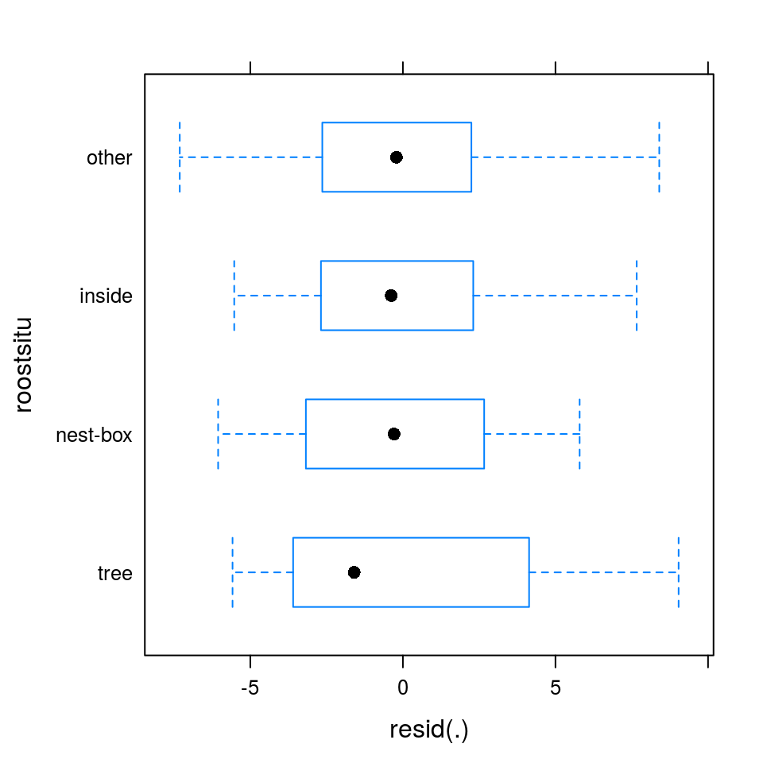

```r
plot(lmer2,roostsitu~resid(.))
```

Plot random effects to look for outliers:

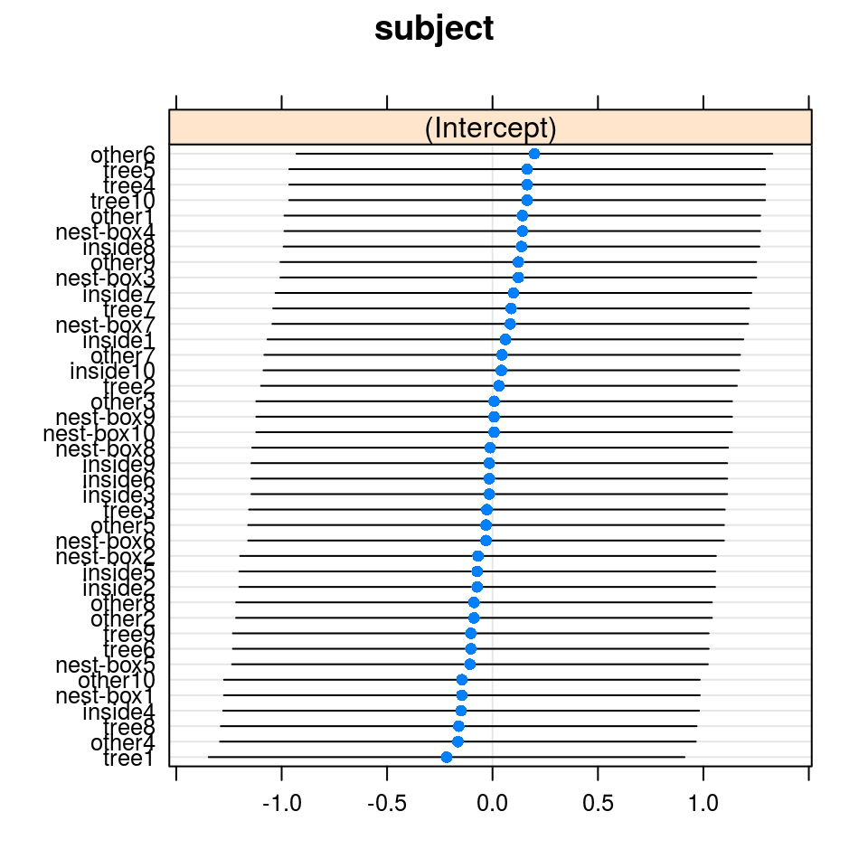

```r
dotplot(ranef(lmer2,condVar=TRUE))
```

In general, try plotting residuals and $\sqrt{\textrm{abs}(r)}$ both as a function of the fitted values and as a function of particularly important predictors.

- if you have your own example data set handy that you can write a simple model for, run these diagnostics and interpret them
- the `hatvalues()` function can also be useful (although all hat values are identical here)
- also see the `influence.ME` package. Try `plot(influence(lmer2,group="subject"))` and interpret the results …

### Try it yourself: tundra carbon example

- Download the file `tundra_agg.rda` (from the data directory given above). The `GS.NEE` records the net ecosystem exchange (in grams of carbon/m^2/year) in a given year and site; `cYear` is a centered version of the year; `n` records the number of observations taken in a given site/year (the NEE value given is an average of these observations).
- Draw some plots (with `ggplot2` if you can, otherwise with base R graphics) to inspect the data
- We are interested in the change in NEE over time (i.e., a random-slopes model). Run an `lmer` fit (note this data set does not have the issue of the starling data set), draw some preliminary conclusions, and inspect the plot diagnostics.

### Analyze with `MCMCglmm`

(optional)

`MCMCglmm` does a Bayesian analysis, which can be useful for more flexible inference, and has some more flexible covariance structures etc.. For basic models, the syntax is very similar to `lme4`/`nlme`.

```r
mcmcglmm1 <- MCMCglmm(stmass~mnth*roostsitu,
                      random=~subject,data=dataf,
                      verbose=FALSE)
```

We use `verbose=FALSE` to turn off the progress messages, which would be ugly in this document but are generally useful.

- Compare the results (use `summary()`: printing out the a raw `MCMCglmm` model is ugly).

For MCMC approaches, it is your responsibility to check that the chain(s) are well-behaved.

Try this:

```r
library("coda")
xyplot(as.mcmc(mcmcglmm1$Sol),layout=c(2,4))
```

You can plot the distributions:

```r
densityplot(mcmcglmm1$Sol)
```

but I prefer *violin plots* for this case:

```r
md <- melt(as.matrix(mcmcglmm1$Sol)) ## change matrix to long form
ggplot(subset(md,Var2!="(Intercept)"),
       aes(Var2,value))+geom_violin(fill="grey")+
    geom_hline(yintercept=0,lty=2)+
    coord_flip()
```

## Inference

One good way to assess the results of a model fit is to look at a coefficient plot:

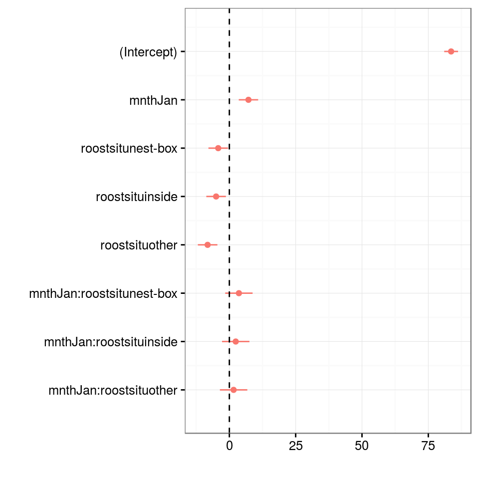

```r
dwplot(lmer2)+geom_vline(xintercept=0,lty=2)
```

(It’s usually a good idea to drop the intercept from coefficient plots: the next release of `dwplot` will have a `drop_intercept` parameter that will do this automatically.) For more complicated coefficient plots, you can use the combination of the `broom` package to get the parameters in a useful form and `dwplot` to draw the plot.

Stop and explain to yourself what these parameters mean. If you’re not sure, try resetting the base level of the `roostsitu` factor: `dataf2 <- transform(dataf,roostsitu=relevel(roostsitu,ref="other"))`, predict what will happen to the results, and re-run the analysis.)

**Exercise**: This is actually a slightly trivial example, because there are only two measurements for each individual. Thus we can actually analyze the slopes and get the same answers by using a paired analysis, i.e. by computing the mass *difference* in subjects and then analyzing with a single-level linear model. (In the simplest case this would reduce to a paired $t$-test, but in this case it is a 1-way ANOVA on `roostsitu`.

Rearrange the data to get differences by subject:

```r
library(plyr)
dataf2 <- ddply(dataf,"subject", summarise,
             roostsitu=roostsitu[1],massdiff=diff(stmass))
```

This says to split the data frame `dataf` by the `subject` variable; for each value of `subject`, put together a data frame with a `roostsitu` variable equal to the first element of the `rootsitu` vector for that subject and a `massdiff` variable equal to the difference between the masses.

Draw a picture (boxplot+beeswarm plot):

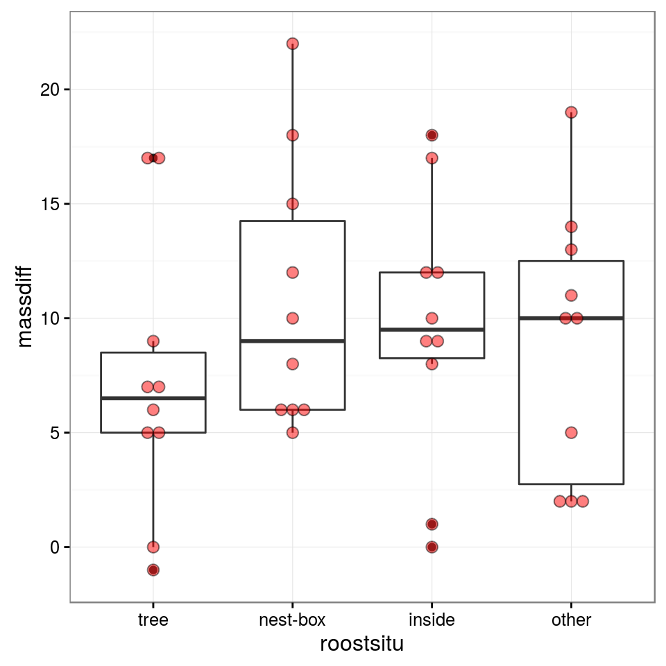

```r
ggplot(dataf2,aes(x=roostsitu,y=massdiff))+geom_boxplot()+
   geom_dotplot(binaxis="y",stackdir="center",fill="red",alpha=0.5,
                binwidth=0.5)
```

As you can see, `geom_dotplot()` adds a horizontal dot-plot for each group (see the documentation [`?geom_dotplot`] for more details).

- Analyze the data with `lm` and convince yourself that the estimates (fixed-effect coefficients, $t$ statistics, etc.) are equivalent to those found from the previous analysis.
- It is also possible to rearrange and summarize the data to test the difference in intercepts, or to estimate the among-individual variance in intercepts (how?)

## Inference part 2

What about $p$-values or more sophisticated confidence intervals? The default confidence intervals shown by `dwplot()` are just Normal confidence intervals (not taking into account any of the effects that make these approximate for mixed models).

We can get profile confidence intervals via `confint(lmer2)`, but the confidence intervals are almost identical to those from `confint(lmer2,method="Wald")` (the default shown by `dwplot()`.

(Insert long discussion of degrees of freedom and $p$-values here.)

We can use `lmerTest` or `afex::mixed` (which both wrap functions from the `pbkrtest` package) to get “denominator degrees of freedom”/$p$-values.

- `lmerTest` wraps the `lmer` function to compute some additional information, and modifies the `summary()` function:

```r
library("lmerTest")
lmer2R <- lmer(stmass~mnth*roostsitu+(1|subject),data=dataf)
detach("package:lmerTest")
```

Capturing just the coefficient table from `summary(lmer2R)`:

```
## Fixed effects:
##                           Estimate Std. Error     df t value Pr(>|t|)
## (Intercept)                 83.600      1.330 71.970  62.847  < 2e-16 ***
## mnthJan                      7.200      1.863 36.000   3.865 0.000446 ***
## roostsitunest-box           -4.200      1.881 71.970  -2.233 0.028685 *
## roostsituinside             -5.000      1.881 71.970  -2.658 0.009682 **
## roostsituother              -8.200      1.881 71.970  -4.359 4.27e-05 ***
## mnthJan:roostsitunest-box    3.600      2.634 36.000   1.367 0.180244
## mnthJan:roostsituinside      2.400      2.634 36.000   0.911 0.368341
## mnthJan:roostsituother       1.600      2.634 36.000   0.607 0.547430
```

By default `lmerTest` uses the Satterthwaite approximation to the degrees of freedom. You can also use `summary(lmer2R,ddf="Kenward-Roger")` to get a slightly more accurate (and slower) estimate, but in this case the answers are basically identical.

We conclude that the interactions are not doing much, but there’s definitely an effect of the roosts and months. This agrees with the picture from `dwplot` (above).

```r
anova(lmer2)
```

```
## Analysis of Variance Table
##                Df  Sum Sq Mean Sq F value
## mnth            1 1656.20 1656.20 95.4582
## roostsitu       3  552.46  184.15 10.6141
## mnth:roostsitu  3   34.20   11.40  0.6571
```

`lmer` doesn’t give denominator degrees of freedom …

If we want to evaluate the *marginal* sums of squares, i.e. dropping one term at a time from the model, when there are interactions, we usually want to change the model to use sum-to-zero contrasts:

```r
lmer2B <- update(lmer2,
          contrasts=list(mnth="contr.sum",roostsitu="contr.sum"))
```

The alternative approach is to use `options(contrasts=c("contr.sum","contr.poly"))`, then refit the model, but I prefer to use the `contrasts` argument because it is more explicit.

- Use `afex::mixed` to do “type 3” tests of all effects in a model (using Kenward-Roger to get df by default).

```r
mixed(stmass~mnth*roostsitu+(1|subject),data=dataf)
```

```
## Fitting 4 (g)lmer() models:
## [....]
## Obtaining 3 p-values:
## [...]
```

```
##           Effect    df F.scaling         F p.value
## 1           mnth 1, 36      1.00 95.46 ***  <.0001
## 2      roostsitu 3, 36      1.00 10.61 ***  <.0001
## 3 mnth:roostsitu 3, 36      1.00      0.66     .58
```

- Use `anova()` to do a likelihood ratio test on individual pairs of models.
- Use `drop1()` to drop terms from the model one at a time
- `nlme::lme` also gives denominator df

```r
lme2 <- lme(stmass~mnth*roostsitu,random=~1|subject,data=dataf,
    contrasts=list(mnth=contr.sum,roostsitu=contr.sum))
anova(lme2,type="marginal")
```

```
##                numDF denDF   F-value p-value
## (Intercept)        1    36 31143.554  <.0001
## mnth               1    36    95.458  <.0001
## roostsitu          3    36    10.614  <.0001
## mnth:roostsitu     3    36     0.657  0.5838
```

**be careful when doing “marginal”/“type 3” tests in the presence of interactions!** Also note that `nlme::lme` gets denominator df calculations wrong for some random-slopes models. If you want to try `lme`’s denominator df calculations without actually fitting the model:

```r
source("R/calcDenDF.R")
calcDenDF(~roostsitu*mnth,"subject",dataf)
```

```
##               (Intercept)         roostsitunest-box
##                        36                        36
##           roostsituinside            roostsituother
##                        36                        36
##                   mnthJan roostsitunest-box:mnthJan
##                        36                        36
##   roostsituinside:mnthJan    roostsituother:mnthJan
##                        36                        36
```

In this case the results ($F$ values) are identical *because the original design is balanced (hence, orthogonal)*. Not true if the data are (1) unbalanced (which is often true of ANOVA [categorical-predictor] designs, and almost always true of regression designs) or (2) GLMM or nonlinear.

The explicit model-comparison approach uses a likelihood ratio test rather than an $F$ test (i.e., it does not correct for the fact that the denominator sums of squares is estimated with error). In this case it hardly matters.

```r
lmer2C <- update(lmer2B,REML=FALSE)
lmer2D <- update(lmer2C,. ~ . - mnth:roostsitu)
anova(lmer2C,lmer2D)
```

```
## Data: dataf
## Models:
## lmer2D: stmass ~ mnth + roostsitu + (1 | subject)
## lmer2C: stmass ~ mnth * roostsitu + (1 | subject)
##        Df    AIC    BIC  logLik deviance  Chisq Chi Df Pr(>Chisq)
## lmer2D  7 464.58 481.25 -225.29   450.58
## lmer2C 10 468.45 492.27 -224.22   448.45 2.1344      3      0.545
```

If we now want to use the model-comparison approach on the reduced (no-interaction) model to test the significance of `roostsitu`, we can use `update` to drop the `roostsitu` effect, but we also have to make sure to update the `contrasts` argument so that it only refers to predictors that remain in the reduced model (otherwise, we get an error).

```r
drop1(lmer2D,test="Chisq") ## ignore warnings
```

```
## Single term deletions
##
## Model:
## stmass ~ mnth + roostsitu + (1 | subject)
##           Df    AIC    LRT   Pr(Chi)
## <none>       464.58
## mnth       1 528.02 65.442 5.986e-16 ***
## roostsitu  3 483.93 25.345 1.308e-05 ***
## ---
## Signif. codes:  0 '***' 0.001 '**' 0.01 '*' 0.05 '.' 0.1 ' ' 1
```

If we want to test the random effect, we would in principle remove the random effect and test with `anova`, but this is a bit problematic here: `lmer` can’t fit a model without any random effects.

Let’s try this with `lm`:

```r
lm1 <- lm(stmass~mnth*roostsitu,data=dataf)
(a1 <- anova(lmer2C,lm1))
```

```
## Data: dataf
## Models:
## lm1: stmass ~ mnth * roostsitu
## lmer2C: stmass ~ mnth * roostsitu + (1 | subject)
##        Df    AIC    BIC  logLik deviance  Chisq Chi Df Pr(>Chisq)
## lm1     9 466.46 487.90 -224.23   448.46
## lmer2C 10 468.45 492.27 -224.22   448.45 0.0152      1      0.902
```

We can also deduce the number of degrees of freedom from standard rules:

```r
with(dataf,table(mnth,roostsitu))
```

```
##      roostsitu
## mnth  tree nest-box inside other
##   Nov   10       10     10    10
##   Jan   10       10     10    10
```

If we think about this in terms of the paired $t$-test, there are 40 comparisons and 4 parameters (one for each roost site)= 36 df.

If you wanted to compute the $p$-values by hand, you could:

```r
a2 <- anova(lmer2B)
fvals <- a2[,"F value"]
numdf <- a2[,"Df"]
dendf <- 36
pf(fvals,numdf,dendf,lower.tail=FALSE)
```

```
## [1] 1.151629e-11 3.833216e-05 5.838288e-01
```

Alternatively, we can try a parametric bootstrap: the `pbkrtest` package can do this, or we can just set it up by hand:

```r
lmer3 <- lmer(stmass~mnth*roostsitu+(1|subject),data=dataf)
lmer4 <- lmer(stmass~mnth+roostsitu+(1|subject),data=dataf)

pboot <- function(m0,m1) {
  s <- simulate(m0)
  L1 <- logLik(refit(m1,s[[1]]))
  L0 <- logLik(refit(m0,s[[1]]))
  2*(L1-L0)
}
pboot(lmer4,lmer3)
```

```
## 'log Lik.' -0.8951999 (df=10)
```

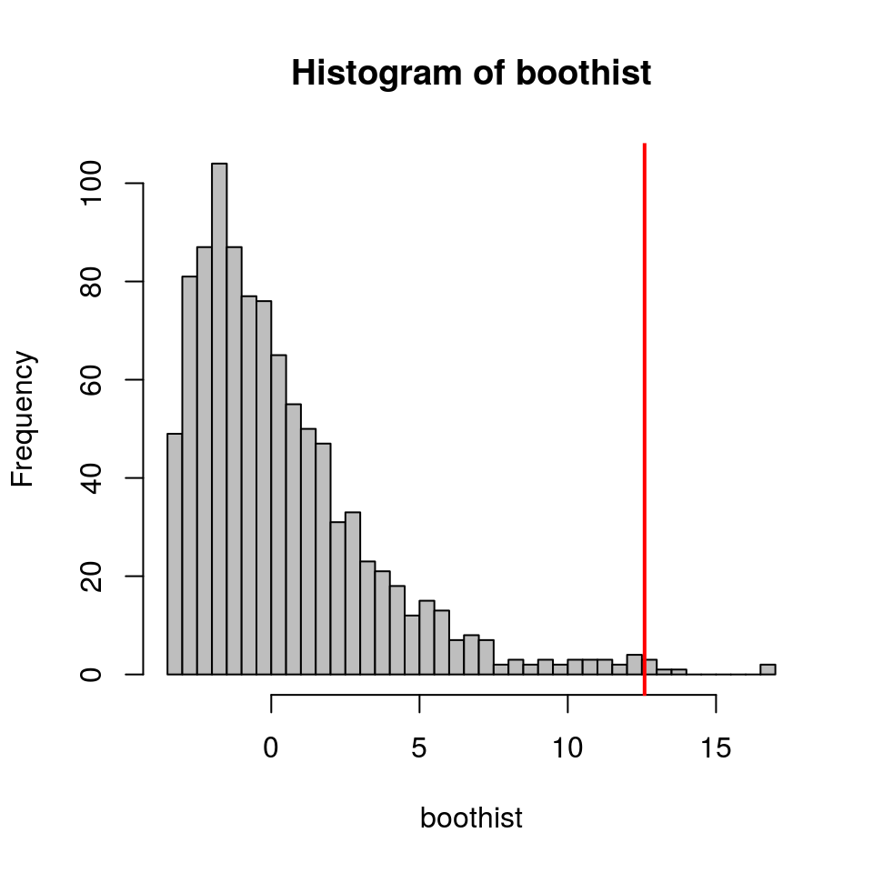

```r
boothist <- replicate(1000,pboot(lmer4,lmer3))
library(plyr)
boothist <- rlply(1000,pboot(lmer4,lmer3))
## can use .progress="text" to get a progress bar ...
boothist <- unlist(boothist)
hist(boothist,breaks=50,col="gray")
obsval <- 2*(logLik(lmer3)-logLik(lmer4))
abline(v=obsval,col=2,lwd=2)
```

```r
mean(boothist>obsval)
```

```
## [1] 0.007
```

```r
library(pbkrtest)
KRmodcomp(lmer3,lmer4)
```

```
## F-test with Kenward-Roger approximation; computing time: 0.06 sec.
## large : stmass ~ mnth * roostsitu + (1 | subject)
## small : stmass ~ mnth + roostsitu + (1 | subject)
##          stat     ndf     ddf F.scaling p.value
## Ftest  0.6571  3.0000 36.0000         1  0.5838
```

In this case, the Kenward-Roger correction appropriately does nothing different – we have a classical balanced design and no correction is actually necessary. But it does give a denominator df and a $p$-value for this lmer model, which is handy …

## Predictions and plotting

In `lmer`, `predict` has a `re.form` argument that specifies which random effects should be included (`NA` or `~0`=none, population level; `NULL` (=all) or `~subject`=prediction at the subject level; more complex models, might have additional nested levels).

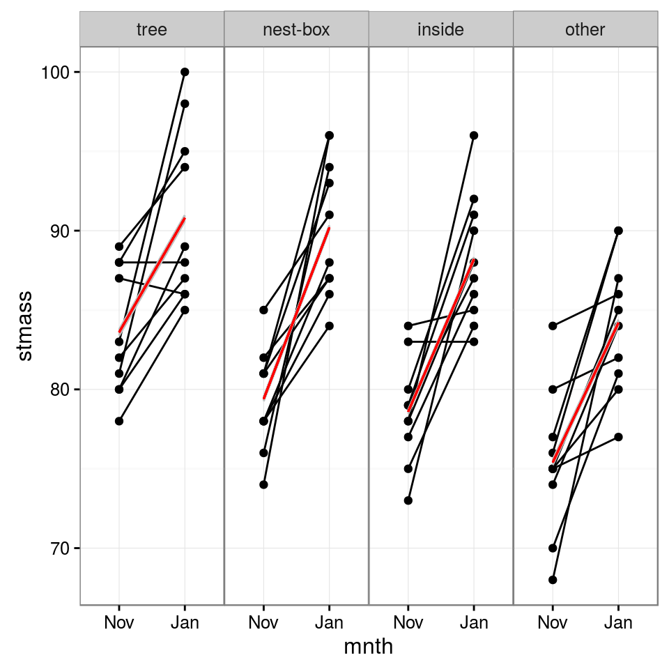

```r
dataf$pred <- predict(lmer2,re.form=NA)  ## population level
dataf$pred1 <- predict(lmer2) ## individual level
g0 <- ggplot(dataf,aes(mnth,stmass))+
  geom_point()+
  geom_line(aes(group=subject))+
  facet_grid(.~roostsitu)+
  zero_margin
g0 +   geom_line(colour="gray",aes(y=pred1,group=subject)) +
    geom_line(colour="red",aes(y=pred,group=subject))
```

There is so much shrinkage (the among-individual variance is very small) that we can barely see the individual-level predictions (gray lines) behind the population-level predictions (red lines).

Unfortunately computing confidence intervals for the predictions is a little tricky: again, there is some code on the [GLMM faq](http://tinyurl.com/glmmfaq) for this (also see below under `MCMCglmm`).

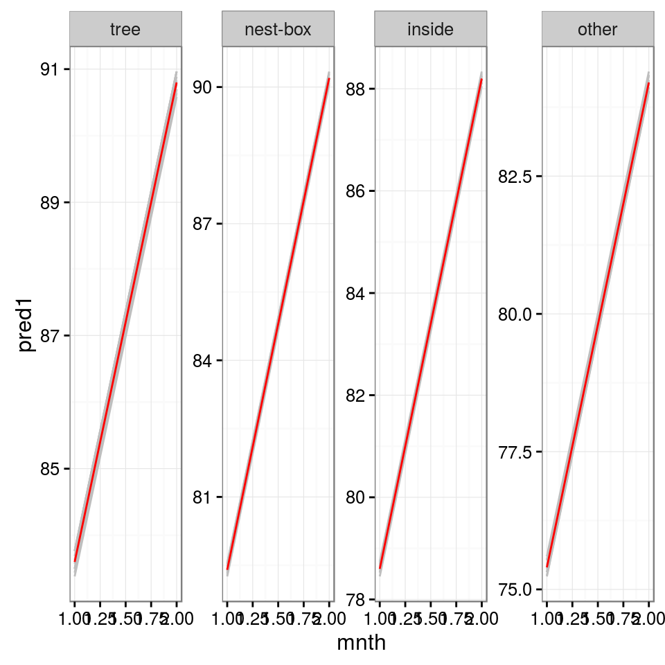

```r
ggplot(dataf,aes(mnth,pred1))+
    geom_line(aes(group=subject,x=as.numeric(mnth)),colour="gray")+
    facet_wrap(~roostsitu,scale="free_y",nrow=1)+
    geom_line(aes(y=pred,x=as.numeric(mnth)),colour="red")
```

For most cases you will want to set up a new data frame to do prediction rather than just using the covariates from the original data (e.g. if the data are sampled irregularly, or sparsely), and use the `newdata` argument of `predict`. The `expand.grid` function is handy in this context too.

### analyze with `MCMCglmm`

```r
summary(mcmcglmm1)
```

```
##
##  Iterations = 3001:12991
##  Thinning interval  = 10
##  Sample size  = 1000
##
##  DIC: 466.8707
##
##  G-structure:  ~subject
##
##         post.mean  l-95% CI  u-95% CI eff.samp
## subject 1.729e-05 9.302e-17 6.855e-05    228.2
##
##  R-structure:  ~units
##
##       post.mean l-95% CI u-95% CI eff.samp
## units     18.18    12.84    24.15    775.1
##
##  Location effects: stmass ~ mnth * roostsitu
##
##                           post.mean l-95% CI u-95% CI eff.samp  pMCMC
## (Intercept)                 83.5977  80.9813  86.1871    805.4 <0.001 ***
## mnthJan                      7.2230   3.1954  10.4924   1000.0 <0.001 ***
## roostsitunest-box           -4.2582  -8.1086  -0.6269   1000.0  0.022 *
## roostsituinside             -4.9430  -8.8462  -1.2175   1000.0  0.012 *
## roostsituother              -8.2557 -12.2054  -4.6783   1042.2 <0.001 ***
## mnthJan:roostsitunest-box    3.6760  -1.5552   9.0938    861.2  0.148
## mnthJan:roostsituinside      2.2303  -2.8774   7.5900   1000.0  0.426
## mnthJan:roostsituother       1.6891  -3.4373   7.2645   1000.0  0.572
## ---
## Signif. codes:  0 '***' 0.001 '**' 0.01 '*' 0.05 '.' 0.1 ' ' 1
```

MCMCglmm makes it a little bit easier to get confidence intervals on the predictions. The `marginal` argument specifies which random effects we want the predictions to “marginalise” (i.e., average over). The default is to use all of the random effects in the original model (i.e. `~subject` in this case), i.e. to predict the average population-level outcome. The approach taken below to get the subject-level predictions (i.e. marginalise over nothing, since `subject` is the only random effect) is a bit of a hack: this may be easier in future versions.

In order to get all the predictions we want, we need to refit the model using `pr=TRUE` to store the random effects (which are sometimes quite large, hence not stored by default):

```r
mcmcglmm1R <- MCMCglmm(stmass~mnth*roostsitu,
         random=~subject,data=dataf,
         verbose=FALSE,pr=TRUE)
```

```r
mpred0 <- predict(mcmcglmm1R,interval="confidence")
colnames(mpred0) <- paste("mpred0",c("fit","lwr","upr"),sep=".")
mpred1 <- predict(mcmcglmm1R,interval="confidence",
                           marginal=NULL)
colnames(mpred1) <- paste("mpred1",c("fit","lwr","upr"),sep=".")
dataf <- data.frame(dataf,mpred0,mpred1)
```

Testing that we get the same results for the level-1 predictions:

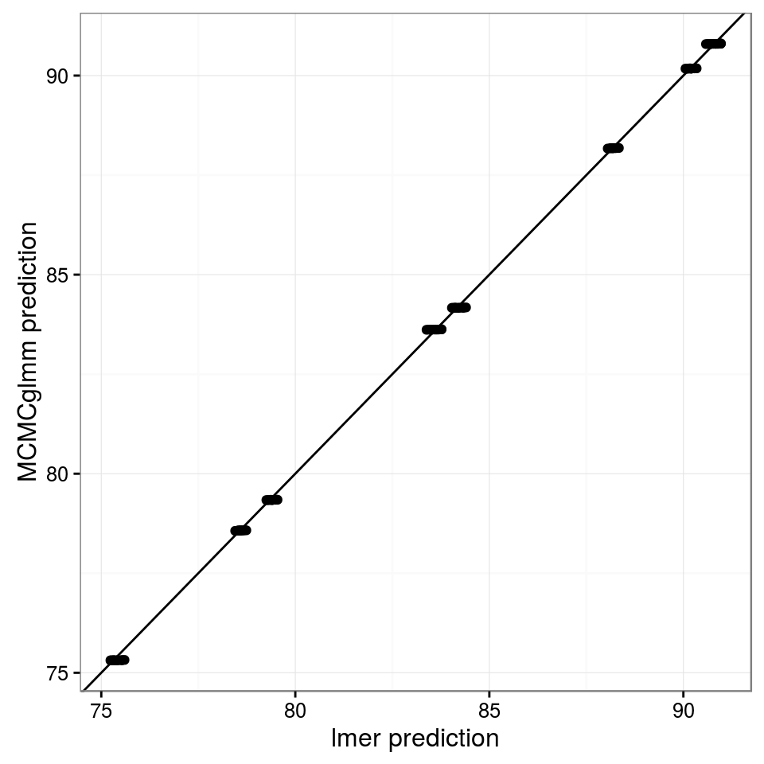

```r
ggplot(dataf,aes(x=pred1,y=mpred1.fit))+geom_point()+
  geom_abline(slope=1,intercept=0)+
  labs(x="lmer prediction",y="MCMCglmm prediction")
```

Now we can plot confidence intervals

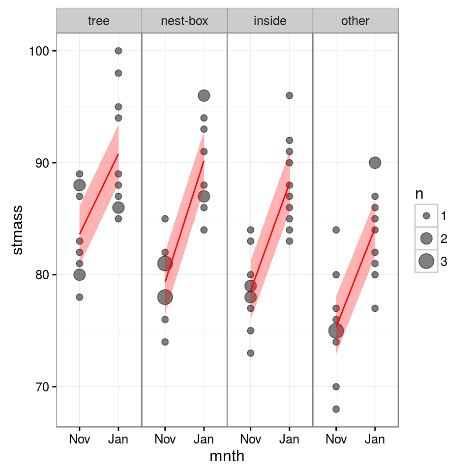

```r
g0 <- ggplot(dataf,aes(x=mnth,y=stmass))+
  stat_sum(aes(size=factor(..n..)),alpha=0.5)+
  facet_grid(~roostsitu)+
  scale_size_discrete(name="n",range=c(2,5))+
  zero_margin
g0 + geom_line(aes(x=as.numeric(mnth),y=mpred0.fit),colour="red")+
  geom_ribbon(aes(x=as.numeric(mnth),y=mpred0.fit,
                  ymin=mpred0.lwr,ymax=mpred0.upr),fill="red",
              alpha=0.3)
```

We can plot individual predictions and confidence intervals as well, although in this case the plot is almost identical:

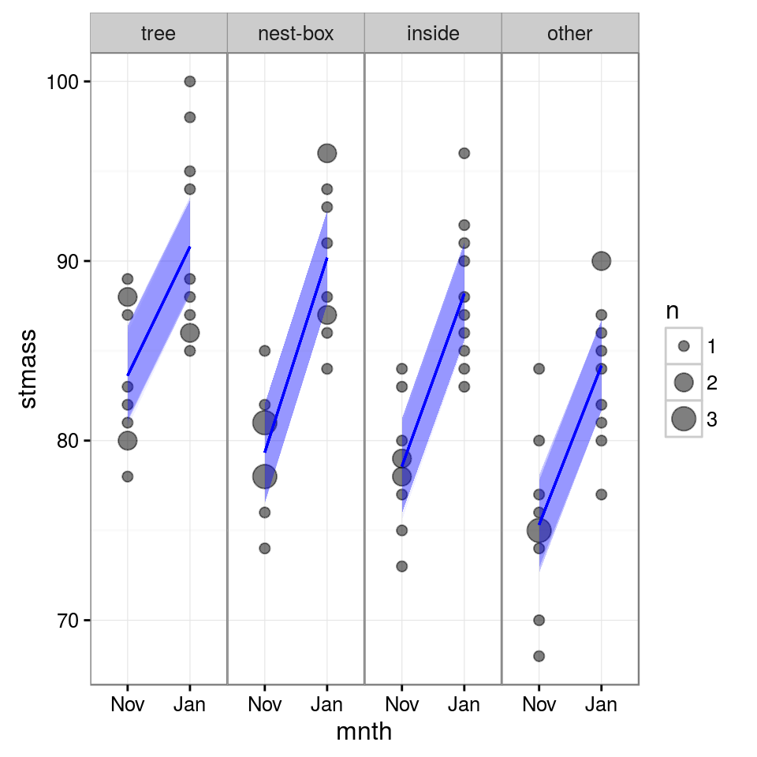

```r
g0 + geom_line(aes(x=as.numeric(mnth),y=mpred1.fit,group=subject),
               colour="blue")+
   geom_ribbon(aes(x=as.numeric(mnth),y=mpred1.fit,group=subject,
                  ymin=mpred1.lwr,ymax=mpred1.upr),fill="blue",
              alpha=0.05)
```

### GLMM stuff

- specify `family` …
- alternative link functions …
- handling overdispersion

### History

- originally developed for NCEAS summer institute, July 2013
- updated, Alaska ASA workshop, August 2014
- updated, Ottawa workshop, Jan 2016 (removed JAGS material)